# Lista 1: respostas

Geometria Analítica 2022.1

Prof. Fernando Náufel

(v. 17/05/2022)

### Applet Geogebra

[Clique aqui para acessar o *applet* Geogebra com as respostas.](https://www.geogebra.org/m/cjqwn6rz)

# 1 Instruções

- Fique à vontade para consultar os coleguinhas e para usar programas como o Geogebra, mas somente soluções *analíticas* serão aceitas — nada de responder no olhômetro.
- Documente da forma mais clara possível todos os passos da resolução de cada questão.
- Entregue (via Moodle) sua resolução escrita no formato que você preferir: manuscrito escaneado ou fotografado, documento gerado via $\LaTeX$ etc. O importante é que a resolução esteja legível. Se você for fotografar sua resolução, use um aplicativo como [Clear Scan](https://play.google.com/store/apps/details?id=com.indymobileapp.document.scanner) para gerar um resultado melhor.
- Além da resolução por escrito, entregue também (via Moodle) um arquivo contendo um vídeo de no máximo 5 minutos onde você explica em detalhes a resolução de uma parte da sua questão.
- Bom trabalho.

# 2 Questão única: construindo uma casa 2D

Veja o seu número nesta lista.

Você vai achar equações para o chão, as paredes, a porta, e o telhado de uma casa no $\mathbb{R}^2$.

Em todos os seus cálculos e respostas, use frações e radicais.

Não use valores numéricos com vírgulas decimais em momento algum.

## Desenho

Sua casa vai ficar assim.

Não, o chão não vai ser horizontal.

A inclinação do chão vai depender do seu número nesta lista.

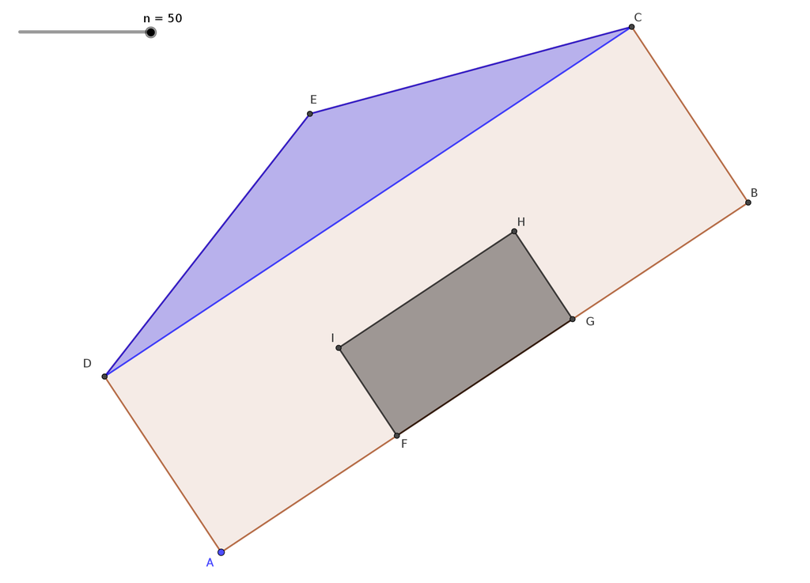

## Chão

- O chão da casa é o segmento que vai do ponto $A$ até o ponto $B$.
- O ponto $A$ é a origem: $A = (0, 0)$.
- Use as coordenadas de $B$ que correspondem ao seu número.
- Comece calculando o vetor $\overrightarrow{AB}$.
  - Chame as coordenadas de $B$ de $(x_B, y_B)$.
  - Então, $\overrightarrow{AB} = (x_B - 0, y_B - 0) = (x_B, y_B)$.
- Depois — vá por mim — ache um vetor unitário na mesma direção e sentido que $\overrightarrow{AB}$.
  - Basta dividir $\overrightarrow{AB}$ pelo seu módulo.
  - $|\overrightarrow{AB}| = \sqrt{x_B^2 + y_B^2}$.
  - Independente das coordenadas do ponto $B$ sorteado para você, este módulo vai ser $12$ (porque eu quis assim).
  - O vetor unitário na mesma direção e sentido de $\overrightarrow{AB}$ vai ser

    $$\overrightarrow{AB_U} = \left( \frac{x_B}{12}, \frac{y_B}{12} \right)$$
- Ache a equação da reta que contém o chão.
  - Paramétricas:

    $\overrightarrow{AB} = (x_B, y_B)$ é um vetor diretor.

    Usando o ponto $A$:

    $$\begin{cases}
    x = 0 + x_B \cdot t \\
    y = 0 + y_B \cdot t
    \end{cases}$$

    Ou, usando o ponto $B$:

    $$\begin{cases}
    x = x_B + x_B \cdot t \\
    y = y_B + y_B \cdot t
    \end{cases}$$
  - Cartesiana:

    Precisamos de um vetor normal (perpendicular) ao chão.

    Podemos usar $\overrightarrow{n_1} = (-y_B, x_B)$ ou $\overrightarrow{n_2} = (y_B, -x_B)$.

    A equação fica

    $$-y_Bx + x_By + \gamma = 0$$

    ou

    $$y_Bx - x_By + \gamma = 0$$

    Como a reta passa pela origem, $\gamma = 0$.

    A equação fica

    $$-y_Bx + x_By = 0$$

    ou

    $$y_Bx - x_By = 0$$
  - Reduzida:

    $$y = \frac{\Delta y}{\Delta x}x + b \iff
    y = \frac{y_B}{x_B}x + b$$
    Como a reta passa pela origem, $b = 0$. A equação fica
    $$y = \frac{y_B}{x_B}x$$
- Coordenadas de $B$ — use o item que corresponde ao valor de $n$ para a sua matrícula:
  1. $\quad B = \left(\frac{4}{15},\;\; \frac{8}{15} \; \sqrt{506}\right)$
  2. $\quad B = \left(\frac{8}{15},\;\; \frac{4}{15} \; \sqrt{2021}\right)$
  3. $\quad B = \left(\frac{4}{5},\;\; \frac{16}{5} \; \sqrt{14}\right)$
  4. $\quad B = \left(\frac{16}{15},\;\; \frac{28}{15} \; \sqrt{41}\right)$
  5. $\quad B = \left(\frac{4}{3},\;\; \frac{16}{3} \; \sqrt{5}\right)$
  6. $\quad B = \left(\frac{8}{5},\;\; \frac{4}{5} \; \sqrt{221}\right)$
  7. $\quad B = \left(\frac{28}{15},\;\; \frac{8}{15} \; \sqrt{494}\right)$
  8. $\quad B = \left(\frac{32}{15},\;\; \frac{4}{15} \; \sqrt{1961}\right)$
  9. $\quad B = \left(\frac{12}{5},\;\; \frac{24}{5} \; \sqrt{6}\right)$
  10. $\quad B = \left(\frac{8}{3},\;\; \frac{4}{3} \; \sqrt{77}\right)$
  11. $\quad B = \left(\frac{44}{15},\;\; \frac{16}{15} \; \sqrt{119}\right)$
  12. $\quad B = \left(\frac{16}{5},\;\; \frac{4}{5} \; \sqrt{209}\right)$
  13. $\quad B = \left(\frac{52}{15},\;\; \frac{32}{15} \; \sqrt{29}\right)$
  14. $\quad B = \left(\frac{56}{15},\;\; \frac{4}{15} \; \sqrt{1829}\right)$
  15. $\quad B = \left(4,\;\; 8 \; \sqrt{2}\right)$
  16. $\quad B = \left(\frac{64}{15},\;\; \frac{4}{15} \; \sqrt{1769}\right)$
  17. $\quad B = \left(\frac{68}{15},\;\; \frac{8}{15} \; \sqrt{434}\right)$
  18. $\quad B = \left(\frac{24}{5},\;\; \frac{12}{5} \; \sqrt{21}\right)$
  19. $\quad B = \left(\frac{76}{15},\;\; \frac{32}{15} \; \sqrt{26}\right)$
  20. $\quad B = \left(\frac{16}{3},\;\; \frac{4}{3} \; \sqrt{65}\right)$
  21. $\quad B = \left(\frac{28}{5},\;\; \frac{16}{5} \; \sqrt{11}\right)$
  22. $\quad B = \left(\frac{88}{15},\;\; \frac{4}{15} \; \sqrt{1541}\right)$
  23. $\quad B = \left(\frac{92}{15},\;\; \frac{8}{15} \; \sqrt{374}\right)$
  24. $\quad B = \left(\frac{32}{5},\;\; \frac{4}{5} \; \sqrt{161}\right)$
  25. $\quad B = \left(\frac{20}{3},\;\; \frac{8}{3} \; \sqrt{14}\right)$
  26. $\quad B = \left(\frac{104}{15},\;\; \frac{4}{15} \; \sqrt{1349}\right)$
  27. $\quad B = \left(\frac{36}{5},\;\; \frac{48}{5}\right)$
  28. $\quad B = \left(\frac{112}{15},\;\; \frac{4}{15} \; \sqrt{1241}\right)$
  29. $\quad B = \left(\frac{116}{15},\;\; \frac{16}{15} \; \sqrt{74}\right)$
  30. $\quad B = \left(8,\;\; 4 \; \sqrt{5}\right)$
  31. $\quad B = \left(\frac{124}{15},\;\; \frac{8}{15} \; \sqrt{266}\right)$
  32. $\quad B = \left(\frac{128}{15},\;\; \frac{4}{15} \; \sqrt{1001}\right)$
  33. $\quad B = \left(\frac{44}{5},\;\; \frac{8}{5} \; \sqrt{26}\right)$
  34. $\quad B = \left(\frac{136}{15},\;\; \frac{4}{15} \; \sqrt{869}\right)$
  35. $\quad B = \left(\frac{28}{3},\;\; \frac{16}{3} \; \sqrt{2}\right)$
  36. $\quad B = \left(\frac{48}{5},\;\; \frac{36}{5}\right)$
  37. $\quad B = \left(\frac{148}{15},\;\; \frac{16}{15} \; \sqrt{41}\right)$
  38. $\quad B = \left(\frac{152}{15},\;\; \frac{4}{15} \; \sqrt{581}\right)$
  39. $\quad B = \left(\frac{52}{5},\;\; \frac{8}{5} \; \sqrt{14}\right)$
  40. $\quad B = \left(\frac{32}{3},\;\; \frac{4}{3} \; \sqrt{17}\right)$
  41. $\quad B = \left(\frac{164}{15},\;\; \frac{8}{15} \; \sqrt{86}\right)$
  42. $\quad B = \left(\frac{56}{5},\;\; \frac{4}{5} \; \sqrt{29}\right)$
  43. $\quad B = \left(\frac{172}{15},\;\; \frac{16}{15} \; \sqrt{11}\right)$
  44. $\quad B = \left(\frac{176}{15},\;\; \frac{4}{15} \; \sqrt{89}\right)$

## Paredes

- A altura das paredes, sem contar o telhado (ou seja, a distância de $A$ a $D$), é $1/3$ da largura da casa.
- As paredes são perpendiculares ao chão.
- Calcule as coordenadas de $C$ e $D$.
  - A largura da casa é a distância de $A$ a $B$, ou, o que dá no mesmo, o módulo do vetor $\overrightarrow{AB}$, que é $12$.
  - Vamos chamar a largura da casa de $L = 12$.
  - A altura das paredes vai ser $L/3 = 4$.
  - Para achar o ponto $D$, basta achar um vetor que seja perpendicular ao chão, com sentido do chão para o teto, com módulo $4$.
  - É aqui que entra o vetor $\overrightarrow{AB_U}$ que achamos antes. Se invertermos a ordem das coordenadas de $\overrightarrow{AB_U}$ e trocarmos o sinal de uma delas, vamos ter o vetor $\overrightarrow{\text{parede}_U}$, um vetor unitário perpendicular ao chão.
  - Como o sentido que queremos é para cima e para a esquerda, a coordenada $x$ do vetor precisa ser negativa, e a coordenada $y$ do vetor precisa ser positiva.
  - Vamos usar $\overrightarrow{\text{parede}_U} = \left( \frac{-y_B}{12}, \frac{x_B}{12}\right)$. Perceba que, como $x_B$ e $y_B$ eram ambos maiores que zero, os sinais das coordenadas ficam como queremos.
  - Como $\overrightarrow{\text{parede}_U}$ é unitário, basta multiplicá-lo por $4$ e somar o resultado às coordenadas de $A$ para achar o ponto $D$:

    $$D = (0, 0) + 4 \cdot \left( \frac{-y_B}{12}, \frac{x_B}{12}\right) = \left( \frac{-y_B}{3}, \frac{x_B}{3}\right)$$
  - Seguindo o mesmo raciocínio para $B$, chegamos ao ponto $C$:

    $$C = (x_B, y_B) + 4 \cdot \left( \frac{-y_B}{12}, \frac{x_B}{12}\right) = \left( x_B - \frac{y_B}{3}, y_B + \frac{x_B}{3}\right)$$
- Escreva as equações das duas retas que contêm as paredes.
  - Equações paramétricas da reta que contém $AD$:

    $$\begin{cases}
    x = -\frac{y_B}{3} \cdot t \\
    y = \frac{x_B}{3} \cdot t
    \end{cases}$$
  - Equação cartesiana da reta que contém $AD$:

    Usando o vetor $\overrightarrow{AB} = (x_B, y_B)$, normal à reta, a equação fica

    $$x_B \cdot x + y_B \cdot y + \gamma = 0$$

    Como $A = (0, 0)$ é ponto desta reta, $\gamma = 0$:

    $$x_B \cdot x + y_B \cdot y = 0$$
  - Equação reduzida da reta que contém $AD$:

    $$y = \frac{\Delta y}{\Delta x}x + b \iff
    y = \frac{-x_B / 3}{y_B / 3}x + b$$

    Como a reta passa pela origem, $b = 0$. Então, a equação fica

    $$y = -\frac{x_B}{y_B}x$$
  - Equações paramétricas da reta que contém $BC$:

    $$\begin{cases}
    x = x_B -\frac{y_B}{3} \cdot t \\
    y = y_B + \frac{x_B}{3} \cdot t
    \end{cases}$$
  - Equação cartesiana da reta que contém $BC$:

    Usando o vetor $\overrightarrow{AB} = (x_B, y_B)$, normal à reta, a equação fica

    $$x_B \cdot x + y_B \cdot y + \gamma = 0$$

    Como $B = (x_B, y_B)$ é ponto desta reta:

    $$x_B \cdot x_B + y_B \cdot y_B + \gamma = 0
    \iff
    \gamma = -\left( x_B^2 + y_B^2 \right)$$

    e a equação fica

    $$x_B \cdot x + y_B \cdot y - \left( x_B^2 + y_B^2 \right) = 0$$

    Ou, como $x_B^2 + y_B^2 = 144$,

    $$x_B \cdot x + y_B \cdot y - 144 = 0$$
  - Equação reduzida da reta que contém $BC$:

    $$\begin{align}
    y = \frac{\Delta y}{\Delta x}x + b
    &\iff
    y = \frac{y_B - y_B - x_B/3}{x_B - x_B + y_B/3}x + b \\
    &\iff
    y = -\frac{x_B}{y_B}x + b
    \end{align}$$

    Como o ponto $B = (x_B, y_B)$ pertence a esta reta:

    $$\begin{align}
    y = -\frac{x_B}{y_B}x + b
    &\iff
    y_B = -\frac{x_B}{y_B}x_B + b \\
    &\iff
    b = \frac{x_B^2}{y_B} + y_b \\
    &\iff
    b = \frac{x_B^2 + y_B^2}{y_B} \\
    &\iff
    b = \frac{144}{y_B}
    \end{align}$$

    E a equação fica

    $$y = -\frac{x_B}{y_B}x + \frac{144}{y_B}$$

## Telhado

- A altura do teto até o topo do telhado (o ponto $E$) é $1/6$ da largura da casa.

  Ou seja, a altura do chão até o topo do telhado é $1/2$ da largura da casa.
- As duas partes do telhado têm o mesmo comprimento.
- Calcule as coordenadas de $E$.
  - A distância do teto ao telhado é $L/6 = 2$.
  - Para achar o ponto $E$, primeiro achamos o ponto médio de $CD$, que vamos chamar de $M$:

    $$\begin{align}
    M
    &= \left(
    \frac{x_B - y_B/3 - y_B/3}{2},\;
    \frac{y_B + x_B/3 + x_B/3}{2}
    \right) \\
    &= \left(
    \frac{x_B}{2} - \frac{y_B}{3},\;
    \frac{y_B}{2} + \frac{x_B}{3}
    \right) \\
    \end{align}$$
  - Agora, multiplicamos o mesmo vetor unitário $\overrightarrow{\text{parede}_U}$ por $2$ e somamos às coordenadas de $M$ para “subir” de $M$ até $E$:

    $$\begin{align}
    E
    &=
    \left(
    \frac{x_B}{2} - \frac{y_B}{3},\;
    \frac{y_B}{2} + \frac{x_B}{3}
    \right) +
    2 \cdot \left( \frac{-y_B}{12}, \frac{x_B}{12}\right) \\
    &=
    \left(
    \frac{x_B - y_B}{2},\;
    \frac{x_B + y_B}{2}
    \right)
    \end{align}$$
- Ache as equações das retas que contêm os lados do telhado.
  - Vamos fazer só as equações paramétricas.
  - Para o lado $ED$, vamos precisar do vetor $\overrightarrow{ED}$:

    $$\begin{align}
    \overrightarrow{ED}
    &=
    \left(
    \frac{-y_B}{3} - \frac{x_B - y_B}{2},\;
    \frac{x_B}{3} - \frac{x_B + y_B}{2}
    \right) \\
    &=
    \left(
    \frac{y_B}{6} - \frac{x_B}{2},\;
    \frac{-y_B}{2} - \frac{x_B}{6}
    \right)
    \end{align}$$
  - Usando o ponto $D$, fazemos as equações paramétricas da reta que contém $ED$:

    $$\begin{cases}
    x = \frac{-y_B}{3} +
    \left( \frac{y_B}{6} - \frac{x_B}{2}\right) \cdot t \\
    y = \frac{x_B}{3} +
    \left( \frac{-y_B}{2} - \frac{x_B}{6} \right) \cdot t
    \end{cases}$$
  - Para o lado $EC$, vamos precisar do vetor $\overrightarrow{EC}$:

    $$\begin{align}
    \overrightarrow{EC}
    &=
    \left(
    x_B - \frac{y_B}{3} - \frac{x_B - y_B}{2},\;
    y_B + \frac{x_B}{3} - \frac{x_B + y_B}{2}
    \right) \\
    &=
    \left(
    \frac{y_B}{6} + \frac{x_B}{2},\;
    \frac{y_B}{2} - \frac{x_B}{6}
    \right)
    \end{align}$$
  - Usando o ponto $C$, fazemos as equações paramétricas da reta que contém $EC$:

    $$\begin{cases}
    x = x_B - \frac{y_B}{3} +
    \left( \frac{y_B}{6} + \frac{x_B}{2} \right) \cdot t \\
    y = y_B + \frac{x_B}{3} +
    \left( \frac{y_B}{2} - \frac{x_B}{6} \right) \cdot t
    \end{cases}$$
- Use o produto escalar para descobrir o ângulo no topo do telhado (no ponto $E$).
  - Usamos as coordenadas de $\overrightarrow{EC}$ e $\overrightarrow{ED}$ para achar o produto escalar:

    $$\begin{align}
    &
    \langle \overrightarrow{EC}, \overrightarrow{ED} \rangle \\
    &=
    \left( \frac{y_B}{6} + \frac{x_B}{2} \right) \cdot
    \left(\frac{y_B}{6} - \frac{x_B}{2} \right)
    \;+\;
    \left( \frac{y_B}{2} - \frac{x_B}{6} \right) \cdot
    \left( \frac{-y_B}{2} - \frac{x_B}{6} \right) \\
    &=
    - \frac29 \cdot \left(x_B^2 + y_B^2\right)
    \end{align}$$

    Lembrando que $|\overrightarrow{AB}| = \sqrt{x_B^2 + y_B^2} = 12$, vemos que $x_B^2 + y_B^2 = 144$.

    Daí, $\langle \overrightarrow{EC}, \overrightarrow{ED} \rangle = -32$.
  - O cosseno do ângulo $\theta$ entre $\overrightarrow{EC}$ e $\overrightarrow{ED}$ vai ser

    $$\cos \theta =
    \frac{\langle \overrightarrow{EC}, \overrightarrow{ED} \rangle}
    {|\overrightarrow{EC}| \cdot |\overrightarrow{ED}|}$$
  - Precisamos do módulo de $\overrightarrow{EC}$ (que, aliás, vai ser igual ao módulo de $\overrightarrow{ED}$, pois os dois lados do telhado têm o mesmo comprimento):

    $$\begin{align}
    |\overrightarrow{EC}| = |\overrightarrow{ED}|
    &=
    \sqrt{
    \left(\frac{y_B}{6} + \frac{x_B}{2}\right)^2
    \;+\;
    \left(\frac{y_B}{2} - \frac{x_B}{6}\right)^2
    }
    \\
    &=
    2\; \sqrt{10}
    \end{align}$$
  - Então

    $$\cos \theta =
    \frac{\langle \overrightarrow{EC}, \overrightarrow{ED} \rangle}
    {|\overrightarrow{EC}| \cdot |\overrightarrow{ED}|} =
    \frac{-32}{(2\;\sqrt{10})^2} = -\frac45$$
  - O que dá (usando uma calculadora):

    $$\theta = \arccos \left( -\frac45 \right) \approx 143^\circ$$
- Use o produto escalar para achar a área do triângulo azul.
  - Na página $70$ do [livro (pdf)](https://canal.cecierj.edu.br/recurso/4690), vemos que a área do triângulo formado pelos vetores $\overrightarrow{EC}$ e $\overrightarrow{ED}$ é

    $$\frac12\;
    \sqrt{
    |\overrightarrow{EC}|^2\;|\overrightarrow{ED}|^2 -
    \langle \overrightarrow{EC}, \overrightarrow{ED} \rangle^2
    }$$
  - No nosso caso, a área fica:

    $$\frac12\;
    \sqrt{
    (2 \sqrt{10})^2\;(2 \sqrt{10})^2 - (-32)^2
    } \;=\; 12$$

## Porta

- A largura da porta é $1/3$ da largura da casa.
- A porta está centralizada horizontalmente na fachada.
- A altura da porta é $1/6$ da largura da casa.
- Calcule as coordenadas de $H$ e $I$.
  - Primeiro, achamos os pontos $F$ e $G$.
  - A largura da porta é $12/3 = 4$.
  - Como a porta está centralizada,

    $$F = A + 4 \cdot \overrightarrow{AB_U}
    = (0, 0) + 4 \cdot \left( \frac{x_B}{12}, \frac{y_B}{12} \right)
    = \left( \frac{x_B}{3}, \frac{y_B}{3} \right)$$
    e

    $$G = A + 8 \cdot \overrightarrow{AB_U}
    = (0, 0) + 8 \cdot \left( \frac{x_B}{12}, \frac{y_B}{12} \right)
    = \left( \frac{2x_B}{3}, \frac{2y_B}{3} \right)$$
  - A altura da porta é $12/6 = 2$.
  - “Subindo” $2$ unidades na direção de $\overrightarrow{\text{parede}_U}$, a partir de $G$, chegamos a $H$:

    $$\begin{align}
    H
    &= G + 2 \cdot \overrightarrow{\text{parede}_U} \\
    &=
    \left( \frac{2x_B}{3}, \frac{2y_B}{3} \right) +
    2 \cdot \left( \frac{-y_B}{12}, \frac{x_B}{12}\right) \\
    &=
    \left( \frac{4x_B - y_B}{6}, \frac{x_B + 4y_B}{6} \right)
    \end{align}$$
  - “Subindo” $2$ unidades na direção de $\overrightarrow{\text{parede}_U}$, a partir de $F$, chegamos a $I$:

    $$\begin{align}
    I
    &= F + 2 \cdot \overrightarrow{\text{parede}_U} \\
    &=
    \left( \frac{x_B}{3}, \frac{y_B}{3} \right) +
    2 \cdot \left( \frac{-y_B}{12}, \frac{x_B}{12}\right) \\
    &=
    \left( \frac{2x_B - y_B}{6}, \frac{x_B + 2y_B}{6} \right)
    \end{align}$$

# 3 Números dos alunos, por matrícula

| matrícula | n |
| --- | --- |
| 119060029 | 33 |
| 122060003 | 24 |
| 122060004 | 35 |
| 122060005 | 26 |
| 122060006 | 4 |
| 122060007 | 29 |
| 122060008 | 6 |
| 122060009 | 32 |
| 122060010 | 7 |
| 122060011 | 17 |
| 122060012 | 14 |
| 122060013 | 37 |
| 122060014 | 38 |
| 122060015 | 23 |
| 122060016 | 39 |
| 122060017 | 15 |
| 122060018 | 12 |
| 122060019 | 36 |
| 122060020 | 22 |
| 122060021 | 5 |
| 122060022 | 18 |
| 122060023 | 19 |
| 122060028 | 27 |
| 122060029 | 21 |
| 122060030 | 30 |
| 122060031 | 16 |
| 122060033 | 42 |
| 122060034 | 9 |
| 122060035 | 10 |
| 122060036 | 13 |
| 122060038 | 2 |
| 122060040 | 1 |
| 122060041 | 3 |
| 215060056 | 40 |
| 220060041 | 28 |
| 221060040 | 8 |
| 221060047 | 11 |
| 622060024 | 20 |
| 622060025 | 25 |
| 622060026 | 31 |
| 622060027 | 34 |
| 822060037 | 41 |